# Reproducible Research Assignment 1

Load the data (i.e. read.csv()). Process/transform the data (if necessary) into a format suitable for your analysis.

```r
getwd()
```

```
## [1] "C:/Users/leona/OneDrive/Desktop/Data Analytics/Courera/Course 5 - Reproducible Research/Assignment 1"
```

```r
setwd("C:/Users/leona/OneDrive/Desktop/Data Analytics/Courera/Course 5 - Reproducible Research/Assignment 1")
getwd()
```

```
## [1] "C:/Users/leona/OneDrive/Desktop/Data Analytics/Courera/Course 5 - Reproducible Research/Assignment 1"
```

```r
DF <- read.csv("activity.csv")
library(dplyr)
head(DF)
```

```
##   steps       date interval
## 1    NA 2012-10-01        0
## 2    NA 2012-10-01        5
## 3    NA 2012-10-01       10
## 4    NA 2012-10-01       15
## 5    NA 2012-10-01       20
## 6    NA 2012-10-01       25
```

```r
tail(DF)
```

```
##       steps       date interval
## 17563    NA 2012-11-30     2330
## 17564    NA 2012-11-30     2335
## 17565    NA 2012-11-30     2340
## 17566    NA 2012-11-30     2345
## 17567    NA 2012-11-30     2350
## 17568    NA 2012-11-30     2355
```

```r
str(DF)
```

```
## 'data.frame':    17568 obs. of  3 variables:
##  $ steps   : int  NA NA NA NA NA NA NA NA NA NA ...
##  $ date    : Factor w/ 61 levels "2012-10-01","2012-10-02",..: 1 1 1 1 1 1 1 1 1 1 ...
##  $ interval: int  0 5 10 15 20 25 30 35 40 45 ...
```

What is mean total number of steps taken per day?

For this part of the assignment, you can ignore the missing values in the dataset.

Calculate the total number of steps taken per day.

If you do not understand the difference between a histogram and a barplot, research the difference between them. Make a histogram of the total number of steps taken each day.

Calculate and report the mean and median of the total number of steps taken per day.

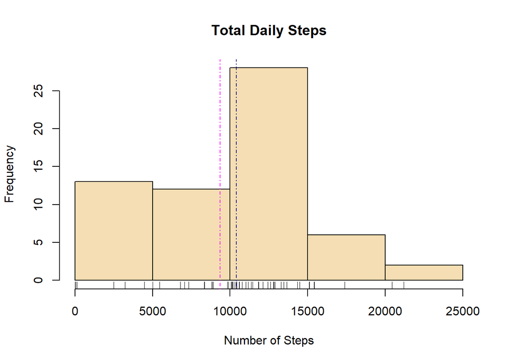

```r
dailytotalsteps <- with(DF, tapply(steps, DF$date, sum, na.rm = TRUE))

hist(dailytotalsteps, main = "Total Daily Steps", xlab = "Number of Steps", col = "wheat")
rug(dailytotalsteps)

meanoftotalsteps <- mean(dailytotalsteps)
medianoftotalsteps <- median(dailytotalsteps)

abline(v = meanoftotalsteps, lwd = 1, lty = 4, col = "magenta")
abline(v = medianoftotalsteps, lwd = 1, lty = 4, col = "dark blue")
```

```r
meanoftotalsteps # Without the NA
```

```
## [1] 9354.23
```

```r
medianoftotalsteps # Without the NA
```

```
## [1] 10395
```

```r
### OR

summary(dailytotalsteps)
```

```
##    Min. 1st Qu.  Median    Mean 3rd Qu.    Max.
##       0    6778   10395    9354   12811   21194
```

What is the average daily activity pattern?

Make a time series plot (i.e. type=“l”) of the 5-minute interval (x-axis) and the average number of steps taken, averaged across all days (y-axis).

Which 5-minute interval, on average across all the days in the dataset, contains the maximum number of steps?

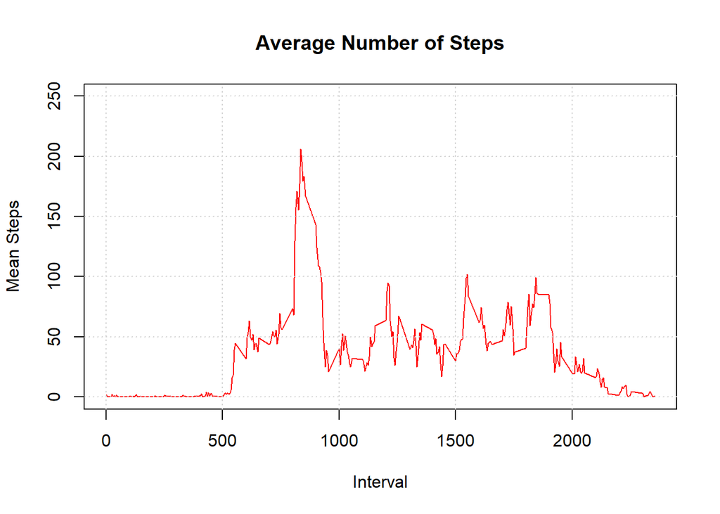

```r
excludeNA <- DF[!is.na(DF$steps),]

interval <- levels(as.factor(excludeNA$interval))
meanSteps <- with(excludeNA, tapply(steps, excludeNA$interval, mean))
medianSteps <- with(excludeNA, tapply(steps, excludeNA$interval, median))

plot(interval, meanSteps, type = "l", col = "red", main = "Average Number of Steps", xlab = "Interval", ylab = "Mean Steps", ylim = c(0, 250))
grid()
```

```r
maxSteps <- which.max(excludeNA$steps)
excludeNA[maxSteps,]
```

```
##       steps       date interval
## 16492   806 2012-11-27      615
```

```r
summary(dailytotalsteps)
```

```
##    Min. 1st Qu.  Median    Mean 3rd Qu.    Max.
##       0    6778   10395    9354   12811   21194
```

```r
summary(excludeNA)
```

```
##      steps                date          interval
##  Min.   :  0.00   2012-10-02:  288   Min.   :   0.0
##  1st Qu.:  0.00   2012-10-03:  288   1st Qu.: 588.8
##  Median :  0.00   2012-10-04:  288   Median :1177.5
##  Mean   : 37.38   2012-10-05:  288   Mean   :1177.5
##  3rd Qu.: 12.00   2012-10-06:  288   3rd Qu.:1766.2
##  Max.   :806.00   2012-10-07:  288   Max.   :2355.0
##                   (Other)   :13536
```

Imputing missing values

Note that there are a number of days/intervals where there are missing values (coded as NA). The presence of missing days may introduce bias into some calculations or summaries of the data.

Calculate and report the total number of missing values in the dataset (i.e. the total number of rows with NAs)

Devise a strategy for filling in all of the missing values in the dataset. The strategy does not need to be sophisticated. For example, you could use the mean/median for that day, or the mean for that 5-minute interval, etc.

Create a new dataset that is equal to the original dataset but with the missing data filled in.

Make a histogram of the total number of steps taken each day and Calculate and report the mean and median total number of steps taken per day. Do these values differ from the estimates from the first part of the assignment? What is the impact of imputing missing data on the estimates of the total daily number of steps?

```r
sum(is.na(DF))
```

```
## [1] 2304
```

```r
NAonly <- DF[is.na(DF$steps),]
NAonly$steps <- meanSteps

head(NAonly)
```

```
##       steps       date interval
## 1 1.7169811 2012-10-01        0
## 2 0.3396226 2012-10-01        5
## 3 0.1320755 2012-10-01       10
## 4 0.1509434 2012-10-01       15
## 5 0.0754717 2012-10-01       20
## 6 2.0943396 2012-10-01       25
```

```r
newDF <- rbind(NAonly, excludeNA)
newDF <- newDF[order(newDF$date),]

head(newDF)
```

```
##       steps       date interval
## 1 1.7169811 2012-10-01        0
## 2 0.3396226 2012-10-01        5
## 3 0.1320755 2012-10-01       10
## 4 0.1509434 2012-10-01       15
## 5 0.0754717 2012-10-01       20
## 6 2.0943396 2012-10-01       25
```

```r
tail(newDF)
```

```
##           steps       date interval
## 17563 2.6037736 2012-11-30     2330
## 17564 4.6981132 2012-11-30     2335
## 17565 3.3018868 2012-11-30     2340
## 17566 0.6415094 2012-11-30     2345
## 17567 0.2264151 2012-11-30     2350
## 17568 1.0754717 2012-11-30     2355
```

```r
str(newDF)
```

```
## 'data.frame':    17568 obs. of  3 variables:
##  $ steps   : num  1.717 0.3396 0.1321 0.1509 0.0755 ...
##  $ date    : Factor w/ 61 levels "2012-10-01","2012-10-02",..: 1 1 1 1 1 1 1 1 1 1 ...
##  $ interval: int  0 5 10 15 20 25 30 35 40 45 ...
```

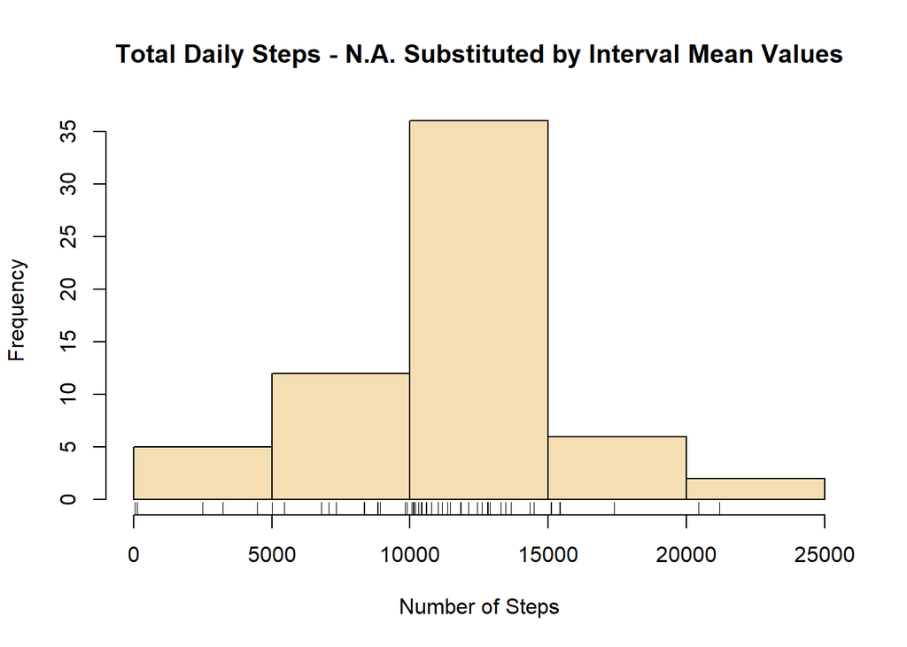

```r
dailytotalsteps2 <- with(newDF, tapply(steps, as.factor(newDF$date), sum))

hist(dailytotalsteps2, main = "Total Daily Steps - N.A. Substituted by Interval Mean Values", xlab = "Number of Steps", col = "wheat")
rug(dailytotalsteps2)
```

```r
meanoftotalsteps2 <- mean(dailytotalsteps2)
medianoftotalsteps2 <- median(dailytotalsteps2)

meanoftotalsteps2
```

```
## [1] 10766.19
```

```r
medianoftotalsteps2
```

```
## [1] 10766.19
```

Are there differences in activity patterns between weekdays and weekends?

For this part the weekdays() function may be of some help here. Use the dataset with the filled-in missing values for this part.

Create a new factor variable in the dataset with two levels - “weekday” and “weekend” indicating whether a given date is a weekday or weekend day.

Make a panel plot containing a time series plot (i.e. type=“l”) of the 5-minute interval (x-axis) and the average number of steps taken, averaged across all weekday days or weekend days (y-axis). See the README file in the GitHub repository to see an example of what this plot should look like using simulated data.

```r
newDF$days <- weekdays(as.Date(newDF$date))
head(newDF)
```

```
##       steps       date interval   days
## 1 1.7169811 2012-10-01        0 Monday
## 2 0.3396226 2012-10-01        5 Monday
## 3 0.1320755 2012-10-01       10 Monday
## 4 0.1509434 2012-10-01       15 Monday
## 5 0.0754717 2012-10-01       20 Monday
## 6 2.0943396 2012-10-01       25 Monday
```

```r
weekendDF <- newDF %>%
        select(steps, date, interval, days) %>%
        filter(days %in% c("Saturday", "Sunday"))
weekdayDF <- newDF %>%
        select(steps, date, interval, days) %>%
        filter(days %in% c("Monday", "Tuesday", "Wednesday", "Thursday", "Friday"))

head(weekdayDF)
```

```
##       steps       date interval   days
## 1 1.7169811 2012-10-01        0 Monday
## 2 0.3396226 2012-10-01        5 Monday
## 3 0.1320755 2012-10-01       10 Monday
## 4 0.1509434 2012-10-01       15 Monday
## 5 0.0754717 2012-10-01       20 Monday
## 6 2.0943396 2012-10-01       25 Monday
```

```r
tail(weekdayDF)
```

```
##           steps       date interval   days
## 12955 2.6037736 2012-11-30     2330 Friday
## 12956 4.6981132 2012-11-30     2335 Friday
## 12957 3.3018868 2012-11-30     2340 Friday
## 12958 0.6415094 2012-11-30     2345 Friday
## 12959 0.2264151 2012-11-30     2350 Friday
## 12960 1.0754717 2012-11-30     2355 Friday
```

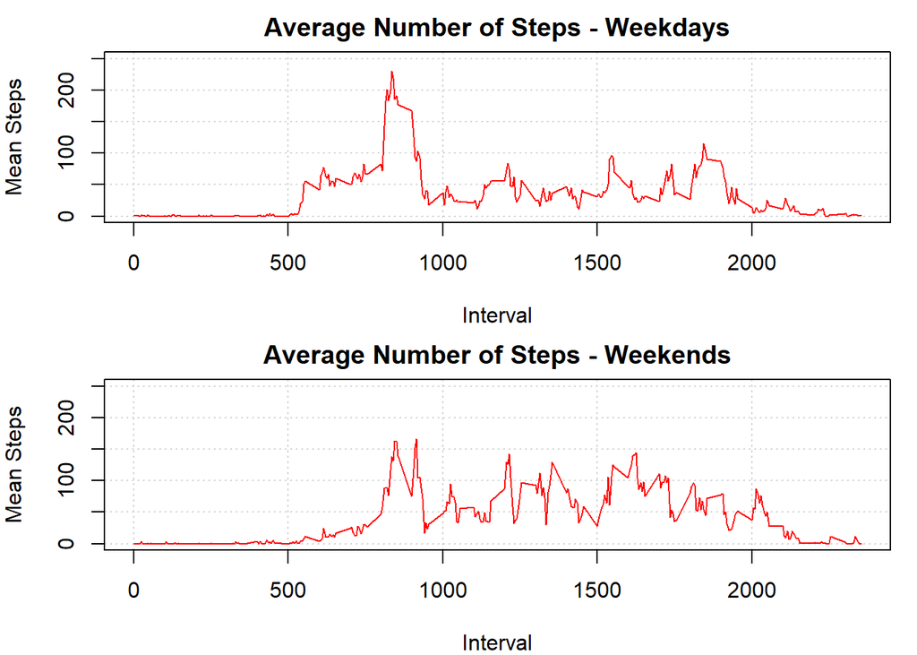

```r
meanweekendDF <- with(weekendDF, tapply(steps, weekendDF$interval, mean))
meanweekdayDF <- with(weekdayDF, tapply(steps, weekdayDF$interval, mean))

par(mfrow = c(2, 1), mar = c(4, 4, 2, 1))
plot(interval, meanweekdayDF, type = "l", col = "red", main = "Average Number of Steps - Weekdays", xlab = "Interval", ylab = "Mean Steps", ylim = c(0, 250), panel.first = grid())
plot(interval, meanweekendDF, type = "l", col = "red", main = "Average Number of Steps - Weekends", xlab = "Interval", ylab = "Mean Steps", ylim = c(0, 250), panel.first = grid())
```